# Initial exploration and comparison of pseudobulk vs. bulk expression

Stephanie J. Spielman

2025-02-26

The goal of this notebook is to compare pseudobulk and bulk calculations to determine which calculation flavors we should proceed with. We compare two pseudobulk and two bulk measures:

- Pseudobulk:
  - `pseudobulk_deseq`: raw counts summed and normalized with `DESeq2`
  - `pseudobulk_log_counts`: raw counts summed and with a `log2(x+1)` transformation
- Bulk:
  - `bulk_counts`: Bulk raw counts normalized with `DESeq2`
  - `bulk_tpm`: TPM bulk data on a `log2` scale

We’ll explore expression distributions, the relationships between bulk and pseudobulk measures, and we’ll also have a brief look at whether there are any genes with strong disagreement between bulk and single-cell.

## Setup

```r
renv::load()
```

```
- Project '~/ALSF/scpca-paper-figures' loaded. [renv 1.1.0]
```

```r
library(ggplot2)
theme_set(theme_bw())
```

### Paths

```r
data_dir <- here::here("analysis", "pseudobulk-bulk-prediction", "data")
tpm_dir <- file.path(data_dir, "tpm")
pseudobulk_dir <- file.path(data_dir, "pseudobulk")
bulk_counts_file <- file.path(data_dir, "normalized-bulk-counts.rds")

tpm_files <- list.files(
  path = tpm_dir,
  full.names = TRUE,
  pattern = "_tpm\\.tsv$"
)
tpm_names <- stringr::str_split_i(basename(tpm_files), pattern = "_", i = 1)
names(tpm_files) <- tpm_names


pseudobulk_files <- list.files(
  path = pseudobulk_dir,
  full.names = TRUE,
  pattern = "_pseudobulk\\.tsv$"
)
pseudobulk_names <- stringr::str_split_i(basename(pseudobulk_files), pattern = "_", i = 1)
names(pseudobulk_files) <- pseudobulk_names

# Make sure we have the same projects, in the same order
stopifnot(
  all.equal(names(tpm_files), names(pseudobulk_files))
)
```

### Read and prepare input data

We’ll make both a long and wide version of the data for convenience throughout the notebook.

```r
project_df_list <- purrr::map2(
  tpm_files,
  pseudobulk_files,
  \(tpm_file, pseudo_file) {

    tpm_df <- readr::read_tsv(tpm_file, show_col_types = FALSE) |>
      #  TPM needs to be in log2 space
      dplyr::mutate(expression = log2(expression))

    pseudo_df <- readr::read_tsv(pseudo_file, show_col_types = FALSE)

    dplyr::bind_rows(
      tpm_df,
      pseudo_df
    ) |>
      tidyr::pivot_wider(
        names_from = expression_type,
        values_from = expression
      )
  }
)
```

We’ll read in the bulk counts data and combine with the rest of the data.

```r
# we only want to keep these samples from the bulk counts
present_samples <- project_df_list |>
  purrr::map(
    \(df) {
      df |>
        dplyr::pull(sample_id) |>
        unique()
    }
  ) |>
  purrr::reduce(c)

# Make a list of data frames of bulk counts, normalized by DESeq2
bulk_df_list <- readr::read_rds(bulk_counts_file) |>
  purrr::map(
    \(df) {
      df |>
        dplyr::filter(sample_id %in% present_samples)
    }
  )

# Combine the data
project_df_list <- purrr::map2(
  bulk_df_list,
  project_df_list,
  \(df_counts, df_main) {

    df_main |>
      dplyr::left_join(df_counts, by = c("ensembl_id", "sample_id"))
  }
)
```

## Full distributions

First, we’ll visualize distributions of all quantities:

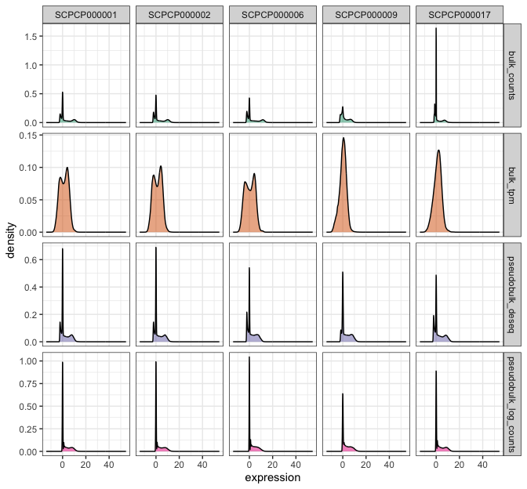

```r
plot_df <- project_df_list |>
  purrr::list_rbind(names_to = "project_id") |>
  tidyr::pivot_longer(
    c(-project_id, -ensembl_id, -sample_id),
    names_to = "expression_type",
    values_to = "expression"
  )

ggplot(plot_df) +
  aes(x = expression, fill = expression_type) +
  geom_density(alpha = 0.5) +
  scale_fill_brewer(palette = "Dark2") +
  facet_grid(
    rows = vars(expression_type),
    cols = vars(project_id),
    scales = "free_y"
  ) +
  theme(legend.position = "none")
```

Let’s clean up for memory here.

```r
rm(plot_df)
gc()
```

```
            used   (Mb) gc trigger   (Mb) limit (Mb)  max used   (Mb)
Ncells   1589086   84.9    2441030  130.4         NA   2441030  130.4
Vcells 186412842 1422.3  459323809 3504.4      51200 459323809 3504.4
```

## Relationship between quantities

This section will look at the relationship among quantities:

- How similar are the pseudobulk measures themselves?
- How does each pseudobulk measure compare to bulk TPM?
  - For these plots, we’ll bin data to see the concentration of overlapping points more easily.
- How does each pseudobulk measure compare to bulk normalized counts (not TPM)?
  - For these plots, we’ll bin data to see the concentration of overlapping points more easily. In all plots, the red line is `y=x`, and the blue line is the regression line.

### Compare pseudobulk measures

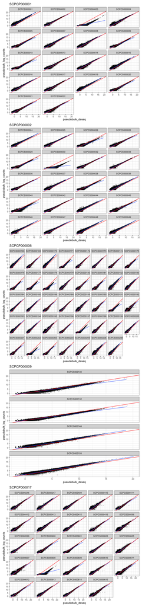

```r
project_df_list |>
  purrr::imap(
    \(df, project_id) {

      ggplot(df) +
        aes(x = pseudobulk_deseq, y = pseudobulk_log_counts) +
        geom_point(alpha = 0.2, size = 0.5) +
        geom_smooth(method = "lm", linewidth = 0.5) +
        geom_abline(linewidth = 0.5, color = "red") +
        facet_wrap(vars(sample_id), nrow = 5) +
        ggtitle(project_id)

    }
  ) |>
  patchwork::wrap_plots(ncol = 1)
```

These quantities are exceptionally similar with these differences:

- Driven by different normalization approaches, genes with very low to zero expression
- In a handful of samples (1-2 per project), `pseudobulk_log_counts` appears to have a higher proportion of low to zero counts, and throughout has lower values than `pseudobulk_deseq`.

### Compare pseudobulk to bulk

Since these quantities here are so similar, these scatterplots will show only bulk comparisons to `pseudobulk_deseq`.

These plots will show:

- Left panel: `bulk TPM ~ pseudobulk_deseq`
- Right panel: `bulk counts ~ pseudobulk_deseq`

```r
# Helper function to visualize scatterplots with geom_bin_2d()
make_binned_scatterplots <- function(df, project_id, nbins, facet_rows) {
  p1 <- ggplot(df) +
    aes(x = pseudobulk_deseq, y = bulk_tpm) +
    geom_bin_2d(bins = nbins) +
    geom_smooth(method = "lm", alpha = 0.8, linewidth = 0.5) +
    geom_abline(alpha = 0.8, linewidth = 0.5, color = "red") +
    facet_wrap(vars(sample_id), nrow = facet_rows) +
    ggtitle("bulk_tpm ~ deseq")

  p2 <- ggplot(df) +
    aes(x = pseudobulk_deseq, y = bulk_counts) +
    geom_bin_2d(bins = nbins) +
    geom_smooth(method = "lm", alpha = 0.8, linewidth = 0.5) +
    geom_abline(alpha = 0.8, linewidth = 0.5, color = "red") +
    facet_wrap(vars(sample_id), nrow = facet_rows) +
    ggtitle("bulk_counts ~ deseq")


  patchwork::wrap_plots(p1, p2, ncol = 2) + patchwork::plot_annotation(title = project_id)
}
```

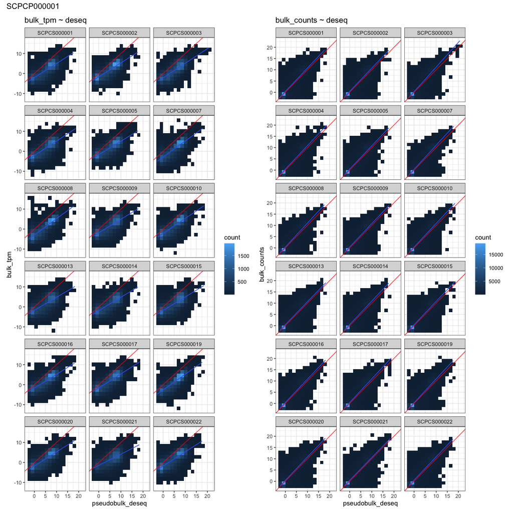

```r
make_binned_scatterplots(
  project_df_list$SCPCP000001,
  project_id = "SCPCP000001",
  nbins = 15,
  facet_rows = 6
)
```

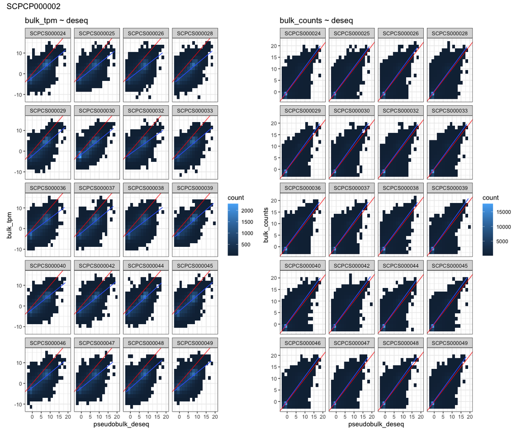

```r
make_binned_scatterplots(
  project_df_list$SCPCP000002,
  project_id = "SCPCP000002",
  nbins = 15,
  facet_rows = 6
)
```

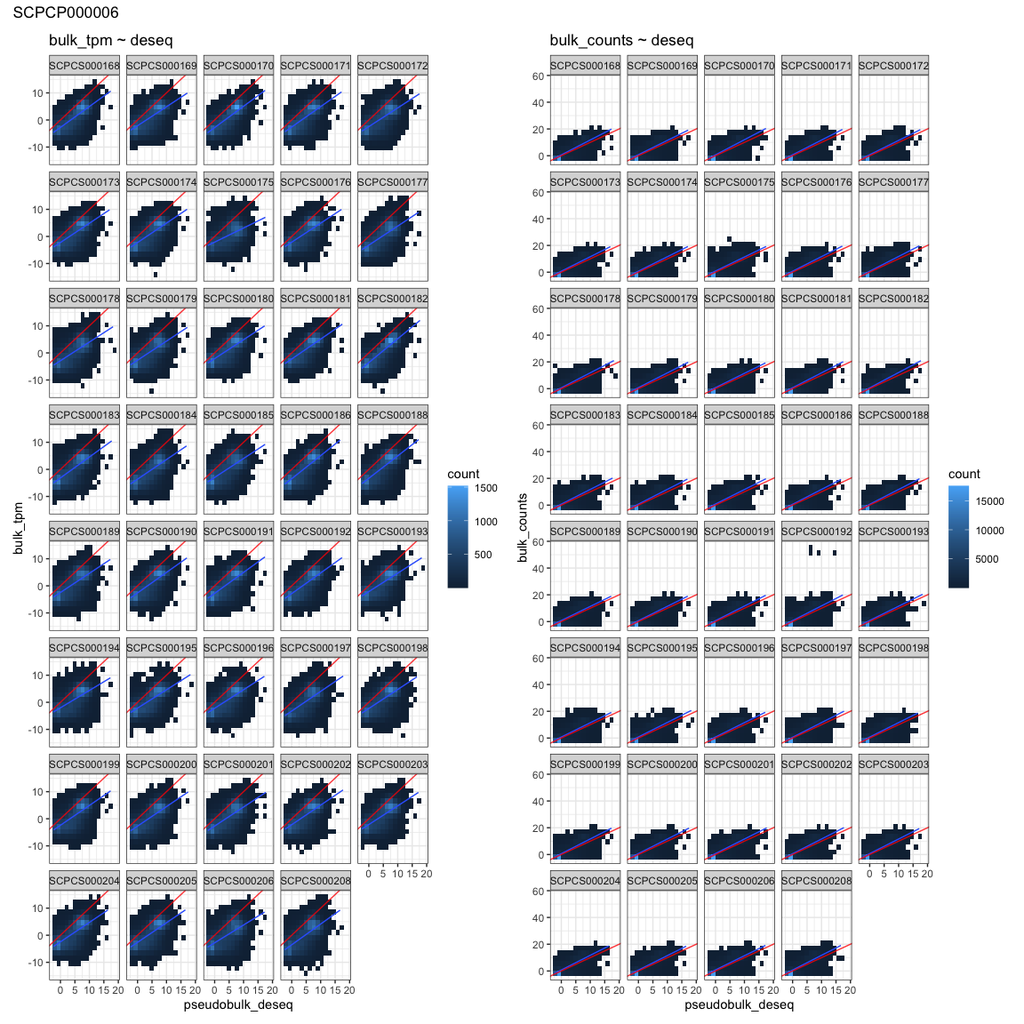

```r
make_binned_scatterplots(
  project_df_list$SCPCP000006,
  project_id = "SCPCP000006",
  nbins = 15,
  facet_rows = 9
)
```

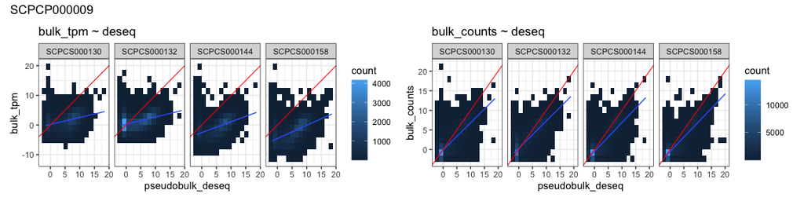

```r
make_binned_scatterplots(
  project_df_list$SCPCP000009,
  project_id = "SCPCP000009",
  nbins = 15,
  facet_rows = 1
)
```

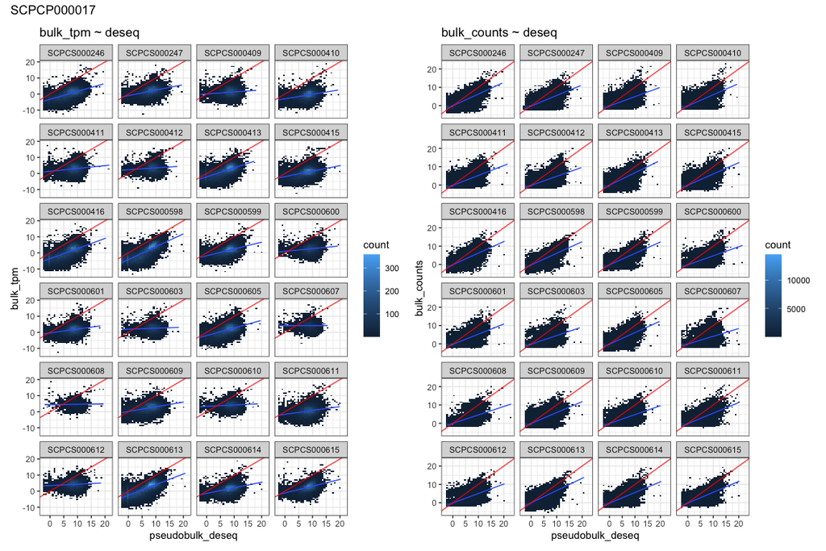

```r
make_binned_scatterplots(
  project_df_list$SCPCP000017,
  project_id = "SCPCP000017",
  nbins = 40,
  facet_rows = 7
)
```

- `bulk_counts` generally has much closer to a 1:1 relationship with pseudobulk compared to `bulk_tpm`
  - This is nearly universally the case for `SCPCP000001`, `SCPCP000002`, and `SCPCP000006`, and while true for `SCPCP000009` and `SCPCP000017`, it is less pronounced
- Relationships in general are weakest for `SCPCP000017`, but the situation does look better with `bulk_counts`

#### Statistics

Let’s nail this down further with correlations comparing each measure for bulk with each measure for pseudobulk. We’ll perform correlations on a per-sample basis, both parametric and non-parametric, display some correlations below both as boxplots and the full table.

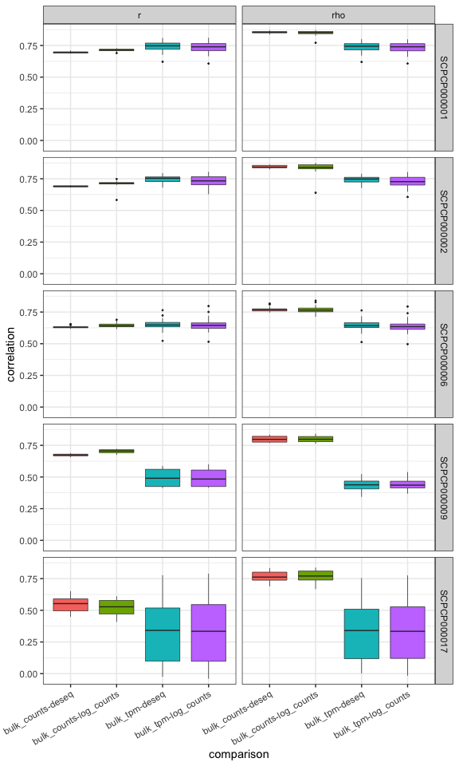

```r
# Helper function to run correlations
model_samples <- function(id, df) {
  sample_df <- df |>
    dplyr::filter(sample_id == id)

  #### Bulk tpm
  df_deseq <- sample_df |>
    dplyr::filter(is.finite(pseudobulk_deseq), is.finite(bulk_tpm))
  r_deseq_tpm <- cor(df_deseq$bulk_tpm, df_deseq$pseudobulk_deseq, method = "spearman")
  rho_deseq_tpm <- cor(df_deseq$bulk_tpm, df_deseq$pseudobulk_deseq, method = "pearson")

  df_log_counts <- sample_df |>
      dplyr::filter(is.finite(pseudobulk_log_counts), is.finite(bulk_tpm))
  r_logcounts_tpm <- cor(df_deseq$bulk_tpm, df_deseq$pseudobulk_log_counts, method = "spearman")
  rho_logcounts_tpm <- cor(df_deseq$bulk_tpm, df_deseq$pseudobulk_log_counts, method = "pearson")

  #### Bulk counts
  df_deseq <- sample_df |>
    dplyr::filter(is.finite(pseudobulk_deseq), is.finite(bulk_counts))
  r_deseq_counts <- cor(df_deseq$bulk_counts, df_deseq$pseudobulk_deseq, method = "spearman")
  rho_deseq_counts <- cor(df_deseq$bulk_counts, df_deseq$pseudobulk_deseq, method = "pearson")

  df_log_counts <- sample_df |>
      dplyr::filter(is.finite(pseudobulk_log_counts), is.finite(bulk_counts))
  r_logcounts_counts <- cor(df_deseq$bulk_counts, df_deseq$pseudobulk_log_counts, method = "spearman")
  rho_logcounts_counts <- cor(df_deseq$bulk_counts, df_deseq$pseudobulk_log_counts, method = "pearson")

  # Tabulate and return some fit stats
  data.frame(
    r =      c(r_deseq_tpm,    r_logcounts_tpm,    r_deseq_counts,   r_logcounts_counts),
    rho =    c(rho_deseq_tpm,  rho_logcounts_tpm,  rho_deseq_counts, rho_logcounts_counts),
    bulk =   c("bulk_tpm",    "bulk_tpm",          "bulk_counts",    "bulk_counts"),
    pseudo = c("deseq",       "log_counts",        "deseq",          "log_counts")
  ) |>
    tidyr::pivot_longer(
      c(r, rho),
      names_to = "measure",
      values_to = "correlation"
    )
}

stats_df <- project_df_list |>
  purrr::map(
    \(df) {

      # We need to map over sample ids now
      samples <- unique(df$sample_id)
      names(samples) <- samples

      fit_table <- samples |>
        purrr::map(model_samples, df) |>
        purrr::list_rbind(names_to = "sample_id")

      return(fit_table)

    }
  ) |>
  # now, combine all projects into a single table
  purrr::list_rbind(names_to = "project_id") |>
  dplyr::mutate(comparison = glue::glue("{bulk}-{pseudo}")) |>
  dplyr::select(-bulk, -pseudo)


ggplot(stats_df) +
  aes(x = comparison, fill = comparison, y = correlation) +
  geom_boxplot(linewidth = 0.25, outlier.size = 0.25)+
  facet_grid(
    rows = vars(project_id),
    cols = vars(measure)) +
  theme(
    legend.position = "none",
    axis.text.x = element_text(angle = 30, hjust = 1)
  )
```

The underlying correlations are here:

```r
stats_df
```

| project_id | sample_id | measure | correlation | comparison |
| --- | --- | --- | --- | --- |
| SCPCP000001 | SCPCS000001 | r | 0.736912862 | bulk_tpm-deseq |
| SCPCP000001 | SCPCS000001 | rho | 0.730909875 | bulk_tpm-deseq |
| SCPCP000001 | SCPCS000001 | r | 0.725482379 | bulk_tpm-log_counts |
| SCPCP000001 | SCPCS000001 | rho | 0.716589750 | bulk_tpm-log_counts |
| SCPCP000001 | SCPCS000001 | r | 0.695399178 | bulk_counts-deseq |
| SCPCP000001 | SCPCS000001 | rho | 0.856760012 | bulk_counts-deseq |
| SCPCP000001 | SCPCS000001 | r | 0.702860991 | bulk_counts-log_counts |
| SCPCP000001 | SCPCS000001 | rho | 0.852631379 | bulk_counts-log_counts |
| SCPCP000001 | SCPCS000002 | r | 0.767726444 | bulk_tpm-deseq |
| SCPCP000001 | SCPCS000002 | rho | 0.765320253 | bulk_tpm-deseq |

[output cut: 830 more lines]

## Disagreeing expression

Based on performances of quantities above, this section considers specifically `bulk_counts` and `pseudobulk_log_counts`.

Next, we’ll take a quick look at cases where one modality has zero expression and the other doesn’t. In these cases, if expression is generally high, we have evidence of disagreement/discrepancy between bulk and single-cell that may be interesting to investigate. In this notebook, we’ll just a sense of how much “there is there,” and we’ll leave the in-depth look into any such genes for a subsequent notebook.

In this section, we’ll also use a threshold of `1e-12` for zero here.

### Bulk counts when single-cell is zero

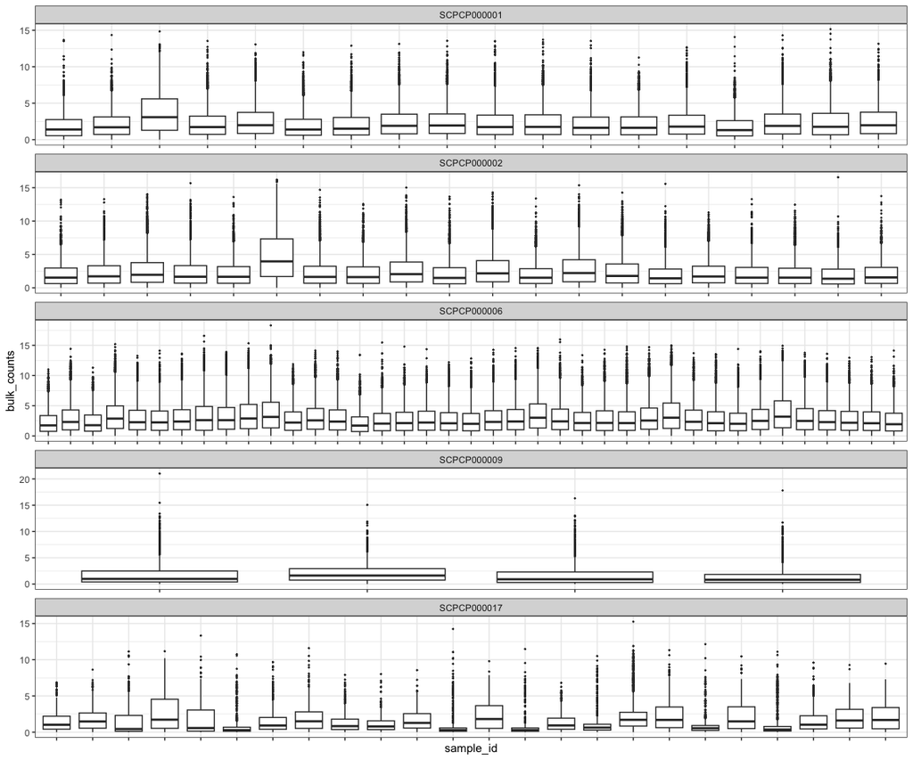

```r
plot_df <- purrr::list_rbind(project_df_list, names_to = "project_id") |>
  dplyr::filter(
    pseudobulk_log_counts <= 1e-12,
    bulk_counts > 1e-12
  )

ggplot(plot_df) +
  aes(x = sample_id, y = bulk_counts) +
  geom_boxplot(outlier.size = 0.25) +
  facet_wrap(vars(project_id), ncol = 1, scale = "free") +
  theme(axis.text.x = element_blank())
```

### Single-cell when bulk counts is zero

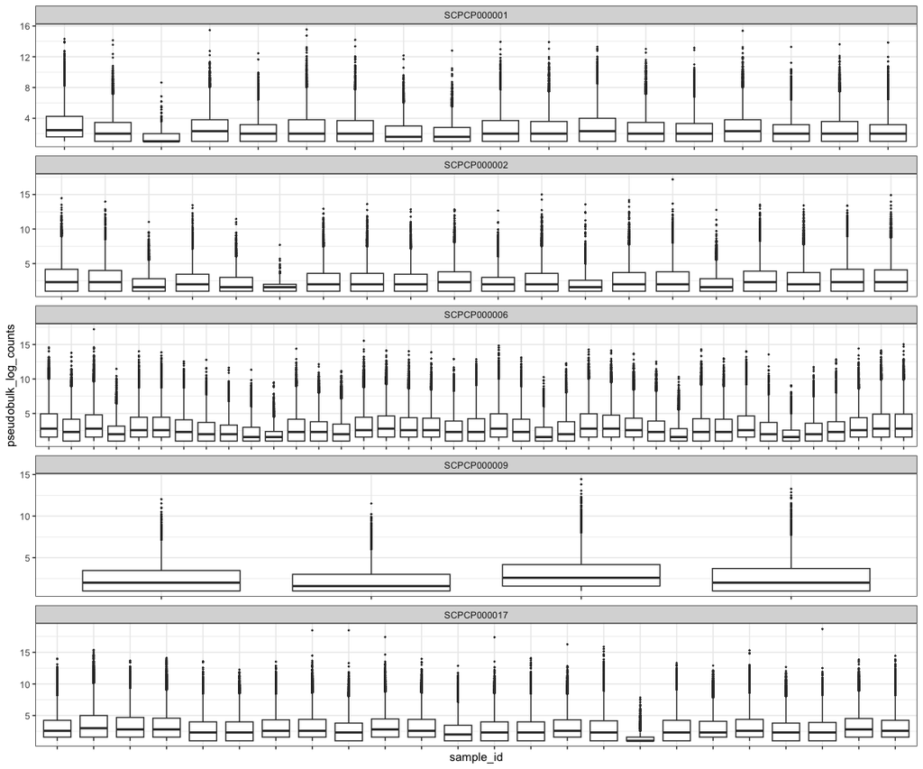

```r
plot_df <- purrr::list_rbind(project_df_list, names_to = "project_id") |>
  dplyr::filter(
    bulk_counts <= 1e-12,
    pseudobulk_log_counts > 1e-12
  )

ggplot(plot_df) +
  aes(x = sample_id, y = pseudobulk_log_counts) +
  geom_boxplot(outlier.size = 0.25) +
  facet_wrap(vars(project_id), ncol = 1, scale = "free") +
  theme(axis.text.x = element_blank())
```

From both comparisons, there’s a decent number of genes with high expression in one modality and essentially zero in the other. A more careful investigation here look into what exactly these genes are, and whether they have some biological relationship that might suggest modalities are picking up different information.